# PR2: Proyecto de Visualización

Luis Oña Riveros

Enero 2025

# 1. Carga de datos

Para empezar, necesitamos cargar el archivo de datos, para después realizar las transformaciones que se piden en el enunciado sobre la variable Region.

```r
# Cargamos el archivo CSV y observamos su estructura
data <- read.csv("portugal_listinigs.csv")

# Vista general del dataset
str(data)
```

```
## 'data.frame':    125457 obs. of  25 variables:
##  $ Price                : num  250000 9500 580000 350000 175000 ...
##  $ District             : chr  "Faro" "Faro" "Faro" "Faro" ...
##  $ City                 : chr  "São Brás de Alportel" "Albufeira" "Vila do Bispo" "Portimão" ...
##  $ Town                 : chr  "São Brás de Alportel" "Albufeira e Olhos de Água" "Budens" "Portimão" ...
##  $ Type                 : chr  "Apartment" "Apartment" "Apartment" "Apartment" ...
##  $ EnergyCertificate    : chr  "A+" "NC" "D" "C" ...
##  $ Floor                : chr  "2nd Floor" "1st Floor" "3rd Floor" "4th Floor" ...
##  $ Parking              : num  1 0 1 0 0 2 3 1 0 0 ...
##  $ HasParking           : chr  "True" "False" "True" "False" ...
##  $ ConstructionYear     : num  NA 1990 2003 1985 1950 ...
##  $ TotalArea            : num  114 27 84 68 78 472 421 15 105 63 ...
##  $ GrossArea            : num  NA NA NA NA NA NA 313 NA 114 NA ...
##  $ EnergyEfficiencyLevel: chr  "" "" "" "" ...
##  $ PublishDate          : chr  "" "" "" "" ...
##  $ Garage               : chr  "" "" "" "" ...
##  $ Elevator             : chr  "True" "True" "False" "True" ...
##  $ ElectricCarsCharging : chr  "" "" "" "" ...
##  $ TotalRooms           : num  2 0 2 2 4 4 7 0 2 1 ...
##  $ NumberOfBedrooms     : num  NA NA NA NA NA NA NA NA NA NA ...
##  $ NumberOfWC           : num  NA NA NA NA NA NA NA NA NA NA ...
##  $ ConservationStatus   : chr  "" "" "" "" ...
##  $ LivingArea           : num  114 27 84 68 78 414 262 15 105 63 ...
##  $ LotSize              : num  NA NA NA NA NA NA NA NA NA NA ...
##  $ BuiltArea            : num  NA NA NA NA NA NA NA NA NA NA ...
##  $ NumberOfBathrooms    : num  2 1 2 1 2 5 NA 0 2 2 ...
```

```r
summary(data)
```

```
##      Price             District             City               Town
##  Min.   :1.000e+00   Length:125457      Length:125457      Length:125457
##  1st Qu.:8.000e+04   Class :character   Class :character   Class :character
##  Median :2.000e+05   Mode  :character   Mode  :character   Mode  :character
##  Mean   :3.669e+05
##  3rd Qu.:3.900e+05
##  Max.   :1.380e+09
##  NA's   :284
##      Type           EnergyCertificate     Floor              Parking
##  Length:125457      Length:125457      Length:125457      Min.   :0.0000
##  Class :character   Class :character   Class :character   1st Qu.:0.0000
##  Mode  :character   Mode  :character   Mode  :character   Median :0.0000
##                                                           Mean   :0.5596
##                                                           3rd Qu.:1.0000
##                                                           Max.   :3.0000
##                                                           NA's   :194
##   HasParking        ConstructionYear   TotalArea            GrossArea
##  Length:125457      Min.   :1900     Min.   :-7.196e+06   Min.   :      -7
##  Class :character   1st Qu.:1972     1st Qu.: 9.300e+01   1st Qu.:     100
##  Mode  :character   Median :1994     Median : 1.680e+02   Median :     164
##                     Mean   :1989     Mean   : 5.542e+05   Mean   :    2790
##                     3rd Qu.:2008     3rd Qu.: 5.510e+02   3rd Qu.:     294
##                     Max.   :2024     Max.   : 6.142e+10   Max.   :12750000
##                     NA's   :43794    NA's   :7542         NA's   :97819
##  EnergyEfficiencyLevel PublishDate           Garage            Elevator
##  Length:125457         Length:125457      Length:125457      Length:125457
##  Class :character      Class :character   Class :character   Class :character
##  Mode  :character      Mode  :character   Mode  :character   Mode  :character
##
##
##
##
##  ElectricCarsCharging   TotalRooms      NumberOfBedrooms   NumberOfWC
##  Length:125457        Min.   :   0.00   Min.   : 0.00    Min.   :-15.00
##  Class :character     1st Qu.:   2.00   1st Qu.: 2.00    1st Qu.:  0.00
##  Mode  :character     Median :   3.00   Median : 3.00    Median :  0.00
##                       Mean   :   3.18   Mean   : 2.68    Mean   :  0.42
##                       3rd Qu.:   4.00   3rd Qu.: 3.00    3rd Qu.:  1.00
##                       Max.   :2751.00   Max.   :21.00    Max.   : 59.00
##                       NA's   :55871     NA's   :86532    NA's   :75228
##  ConservationStatus   LivingArea         LotSize            BuiltArea
##  Length:125457      Min.   :      0   Min.   :        0   Min.   :      -1
##  Class :character   1st Qu.:     80   1st Qu.:      283   1st Qu.:     105
##  Mode  :character   Median :    120   Median :      744   Median :     171
##                     Mean   :   1471   Mean   :    63344   Mean   :    3335
##                     3rd Qu.:    210   3rd Qu.:     3120   3rd Qu.:     308
##                     Max.   :5429000   Max.   :992301000   Max.   :12750000
##                     NA's   :29153     NA's   :90979       NA's   :102668
##  NumberOfBathrooms
##  Min.   :-13.000
##  1st Qu.:  0.000
##  Median :  1.000
##  Mean   :  1.526
##  3rd Qu.:  2.000
##  Max.   : 90.000
##  NA's   :6153
```

```r
dim(data) # Dimensiones del dataset
```

```
## [1] 125457     25
```

# 2. Limpieza de datos

Para la limpieza de datos, primero vamos a ver cuantos valores nulos y en blanco tenemos en nuestro data set.

```r
# Detección de nulos
print("NULOS:")
```

```
## [1] "NULOS:"
```

```r
missing_values <- colSums(is.na(data))
print(missing_values)
```

```
##                 Price              District                  City
##                   284                     0                     0
##                  Town                  Type     EnergyCertificate
##                     0                     0                     0
##                 Floor               Parking            HasParking
##                     0                   194                     0
##      ConstructionYear             TotalArea             GrossArea
##                 43794                  7542                 97819
## EnergyEfficiencyLevel           PublishDate                Garage
##                     0                     0                     0
##              Elevator  ElectricCarsCharging            TotalRooms
##                     0                     0                 55871
##      NumberOfBedrooms            NumberOfWC    ConservationStatus
##                 86532                 75228                     0
##            LivingArea               LotSize             BuiltArea
##                 29153                 90979                102668
##     NumberOfBathrooms
##                  6153
```

```r
# Verificamos valores en blanco
print("EN BLANCO:")
```

```
## [1] "EN BLANCO:"
```

```r
blank_values <- colSums(data == "", na.rm = TRUE)
print(blank_values)
```

```
##                 Price              District                  City
##                     0                     0                     0
##                  Town                  Type     EnergyCertificate
##                     2                    16                    14
##                 Floor               Parking            HasParking
##                 97528                     0                 57242
##      ConstructionYear             TotalArea             GrossArea
##                     0                     0                     0
## EnergyEfficiencyLevel           PublishDate                Garage
##                 68247                103250                 68247
##              Elevator  ElectricCarsCharging            TotalRooms
##                    32                 68247                     0
##      NumberOfBedrooms            NumberOfWC    ConservationStatus
##                     0                     0                108893
##            LivingArea               LotSize             BuiltArea
##                     0                     0                     0
##     NumberOfBathrooms
##                     0
```

Nuestro conjunto de datos contiene **25 variables y 125.457**. Teniendo esto en cuenta, podemos observar que variables como **GrossArea, NumberOfBedrooms, NumberOfWC, LotSize y BuiltArea como mínimo contienen el 50% de registros a nulo.** Por ello, **eliminamos dichas variables** de nuestro conjunto de datos y asi reducir la dimensionalidad del data set. Lo mismo sucede **respecto a los en blanco con las variables Floor, EnergyEfficiencyLevel, PublishDate, Garage, ElectricCarsCharging y ConservationStatus**.

Cabe recalcar, que también se dan casos donde hay nulos o en blanco, pero con menos afectación de cara a sus respectivas variables. Para las variables con menos nulos o en blanco eliminaremos los registros con estos valores para así evitar cualquier tipo de sesgo.

Otros casos como el de la variable HasParking con bastantes valores en blanco, nos decantamos por eliminarlo porque en su caso tenemos la variable Parking, que es similar y podemos extraer la misma conclusión con dicha variable.

```r
# Eliminamos registros nulos en columnas críticas
data <- data %>% filter(!is.na(Price), !is.na(Parking), !is.na(ConstructionYear), !is.na(TotalRooms))

# Eliminamos registros en blanco en columnas críticas
data <- data %>% filter(!(Town == "" | Type == "" | EnergyCertificate == "" | Elevator == ""))

# Eliminamos variables con demasiados valores nulos (>50%)
data <- data %>% select(-GrossArea, -NumberOfBedrooms, -NumberOfWC, -LotSize, -BuiltArea, -Floor, -EnergyEfficiencyLevel, -PublishDate, -Garage, -ElectricCarsCharging, -ConservationStatus, -HasParking, -Town)

# Vertificamos los nulos restantes
missing_values <- colSums(is.na(data))
print(missing_values)
```

```
##             Price          District              City              Type
##                 0                 0                 0                 0
## EnergyCertificate           Parking  ConstructionYear         TotalArea
##                 0                 0                 0                26
##          Elevator        TotalRooms        LivingArea NumberOfBathrooms
##                 0                 0               895               636
```

```r
# Eliminamos los nulos restantes
data <- data %>% filter(!is.na(TotalArea), !is.na(LivingArea), !is.na(NumberOfBathrooms))

# Observamos cuantos valores en blanco quedan despues de eliminar los nulos
blank_values <- colSums(data == "", na.rm = TRUE)
print(blank_values)
```

```
##             Price          District              City              Type
##                 0                 0                 0                 0
## EnergyCertificate           Parking  ConstructionYear         TotalArea
##                 0                 0                 0                 0
##          Elevator        TotalRooms        LivingArea NumberOfBathrooms
##                 0                 0                 0                 0
```

```r
summary(data)
```

```
##      Price             District             City               Type
##  Min.   :6.000e+02   Length:55086       Length:55086       Length:55086
##  1st Qu.:1.499e+05   Class :character   Class :character   Class :character
##  Median :2.470e+05   Mode  :character   Mode  :character   Mode  :character
##  Mean   :4.077e+05
##  3rd Qu.:4.250e+05
##  Max.   :1.380e+09
##  EnergyCertificate     Parking       ConstructionYear   TotalArea
##  Length:55086       Min.   :0.0000   Min.   :1900     Min.   :    -271
##  Class :character   1st Qu.:0.0000   1st Qu.:1972     1st Qu.:      87
##  Mode  :character   Median :0.0000   Median :1993     Median :     139
##                     Mean   :0.7951   Mean   :1989     Mean   :    8182
##                     3rd Qu.:1.0000   3rd Qu.:2008     3rd Qu.:     308
##                     Max.   :3.0000   Max.   :2024     Max.   :90750000
##    Elevator           TotalRooms         LivingArea       NumberOfBathrooms
##  Length:55086       Min.   :   0.000   Min.   :     0.0   Min.   :-1.000
##  Class :character   1st Qu.:   2.000   1st Qu.:    77.0   1st Qu.: 1.000
##  Mode  :character   Median :   3.000   Median :   112.0   Median : 2.000
##                     Mean   :   3.356   Mean   :   618.8   Mean   : 2.007
##                     3rd Qu.:   4.000   3rd Qu.:   180.0   3rd Qu.: 3.000
##                     Max.   :2751.000   Max.   :920000.0   Max.   :90.000
```

Ahora procedemos a transformar las variables restantes:

- **TotalArea, NumberOfBathrooms y TotalRooms:** Solo aceptamos valores positivos. No pueden darse casos negativos como podemos observar en el summary anterior.
- **District y City:** Filtramos aquellos distritos que superen o igualen los 500 registros, y realizamos lo mismo con las ciudades pero que superen o igualen los 200 registros.
- **Price:** Filtramos viviendas por encima o igual a 50.000€ en su precio. Hemos encontrado casos inferiores a 1.000€ que no tienen sentido mantenerlos en el conjunto de datos.
- **ConstructionYear:** Nos centramos en el intervalo de 1950 al 2024.
- **EnergyCertificate:** La categoria ‘NC’ la transformamos en ‘No Certificate’.
- **lat y long:** Obtenemos la latitud y longitud de los distritos para poder visualizarlos en un mapa.

```r
# Eliminamos valores negativos o iguales a 0 en TotalArea y NumberOfBathrooms porque no tiene sentido vender casas o pisos sin baño o Área
data <- data %>% filter(TotalArea > 0, NumberOfBathrooms > 0, TotalRooms > 0)

# Filtramos distritos con al menos 500 registros
district_counts <- data %>%
  group_by(District) %>%
  summarise(Count = n()) %>%
  filter(Count >= 500)

data <- data %>% filter(District %in% district_counts$District)

# Filtramos ciudades con al menos 200 registros
city_counts <- data %>%
  group_by(City) %>%
  summarise(Count = n()) %>%
  filter(Count >= 200)

data <- data %>% filter(City %in% city_counts$City)

# Filtramos los precios superiores o iguales a 50000 y lo redondeamos
data <- data %>% filter(Price >= 50000)
data$Price <- round(data$Price)

# Filtramos propiedades construidas a partir del año 1950 (incluido)
data <- data %>% filter(ConstructionYear >= 1950)

# Cambiamos "NC" a "No Certificate" en la variable EnergyCertificate
data$EnergyCertificate <- ifelse(data$EnergyCertificate == "NC", "No Certificate", data$EnergyCertificate)

# Obtenemos los distritos que tenemos
unique_districts <- data %>%
  distinct(District) %>%
  rename(address = District)

# Para obtener su latitud y longitud
geocoded_districts <- unique_districts %>%
  geocode(address, method = "osm", full_results = FALSE)
```

```
## Passing 12 addresses to the Nominatim single address geocoder
```

```
## Query completed in: 12.1 seconds
```

```r
# Unimos las coordenadas con el dataset original
data <- data %>%
  left_join(geocoded_districts, by = c("District" = "address"))
```

Ya hemos realizado las transformaciones necesarias a nuestro conjunto de datos, nos hemos quedado con 31.665 registros y 14 variables. Ahora vamos a visualizar algunas de las variables para hacernos una idea de lo que nos podemos encontrar en el momento de visualizar lso datos.

```r
# Promedio de precios por región
district_prices <- data %>%
  group_by(District) %>%
  summarise(AveragePrice = mean(Price, na.rm = TRUE),
            Count = n()) %>%
  arrange(desc(AveragePrice))
print(district_prices)
```

```
## # A tibble: 12 × 3
##    District         AveragePrice Count
##    <chr>                   <dbl> <int>
##  1 Faro                 1152625.  2394
##  2 Lisboa                603144. 13611
##  3 Setúbal               406262.  4413
##  4 Porto                 376644.  4743
##  5 Aveiro                374593.   778
##  6 Évora                 371291.   261
##  7 Viana do Castelo      360780.   216
##  8 Braga                 302145.  1848
##  9 Leiria                288147.  1456
## 10 Coimbra               280419.  1140
## 11 Santarém              246046.   565
## 12 Castelo Branco        176672.   240
```

```r
# Distribución de precios según el tipo de propiedad
type_prices <- data %>%
  group_by(Type) %>%
  summarise(AveragePrice = mean(Price, na.rm = TRUE),
            Count = n()) %>%
  arrange(desc(AveragePrice))
print(type_prices)
```

```
## # A tibble: 19 × 3
##    Type                AveragePrice Count
##    <chr>                      <dbl> <int>
##  1 Mansion                 6600000      3
##  2 Estate                  3100000      1
##  3 Hotel                   1670429.     7
##  4 Farm                    1244209.   170
##  5 Industrial               832500      2
##  6 Duplex                   808558.   171
##  7 House                    775468. 10089
##  8 Building                 747033.   396
##  9 Warehouse                535244.    32
## 10 Other - Commercial       529608.    36
## 11 Land                     484128.    43
## 12 Apartment                384412. 20320
## 13 Investment               320760     25
## 14 Store                    320617.   235
## 15 Office                   302331.    51
## 16 Transfer of lease        300586.    36
## 17 Garage                   265000      4
## 18 Studio                   205968.    39
## 19 Other - Residential      157600      5
```

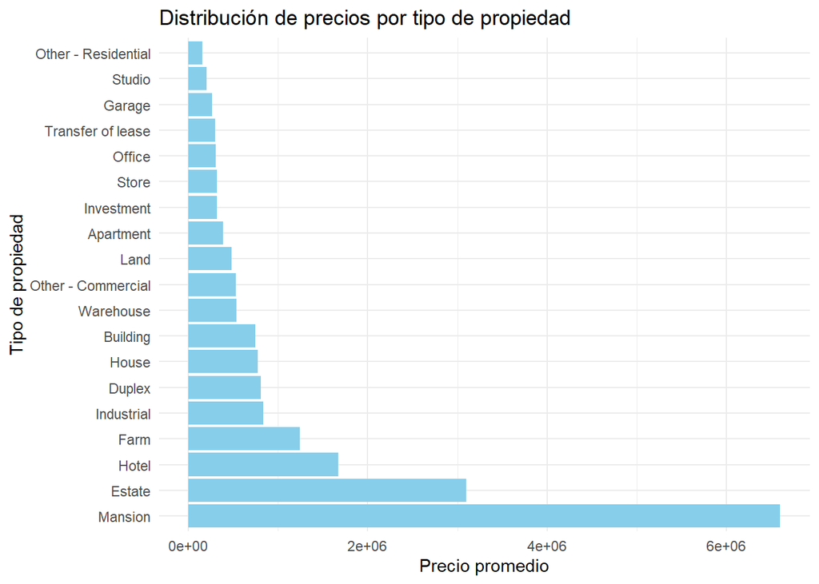

```r
# Visualización de la distribución de precios por tipo de propiedad
ggplot(type_prices, aes(x = reorder(Type, -AveragePrice), y = AveragePrice)) +
  geom_bar(stat = "identity", fill = "skyblue") +
  theme_minimal() +
  labs(title = "Distribución de precios por tipo de propiedad",
       x = "Tipo de propiedad",
       y = "Precio promedio") +
  coord_flip()
```

Depués de ver la distribución de la variable Type, decidimos mantener aquellos registro que o bien sean casas (House) o Pisos/Apartamentos (Apartment).

- **Type:** Nos quedamos sólo con las categorias “House” y “Apartment”.

Y visualizaremos los boxplots de las variables “TotalRooms”, “TotalArea”, “LivingArea” y “NumberOfBathrooms” para ver si tienen outliers y eliminarlos en caso de que tengan.

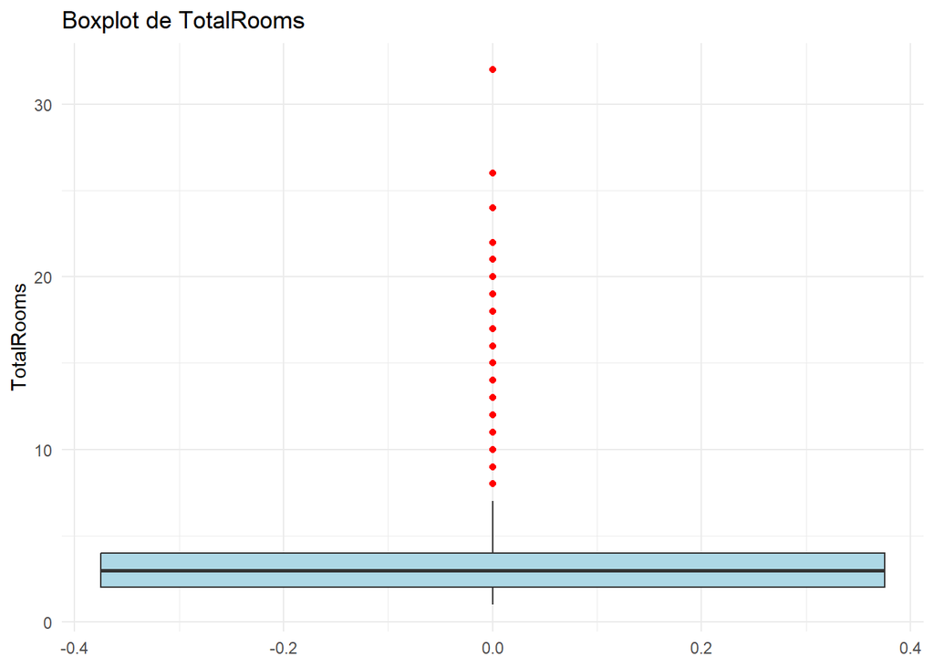

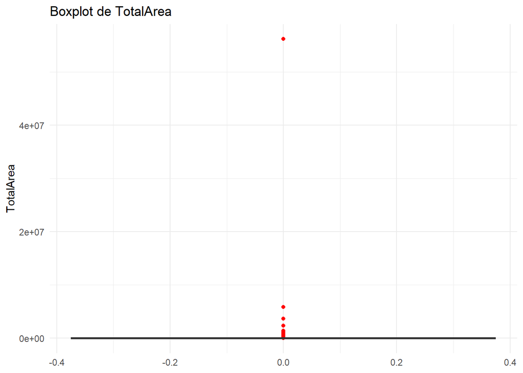

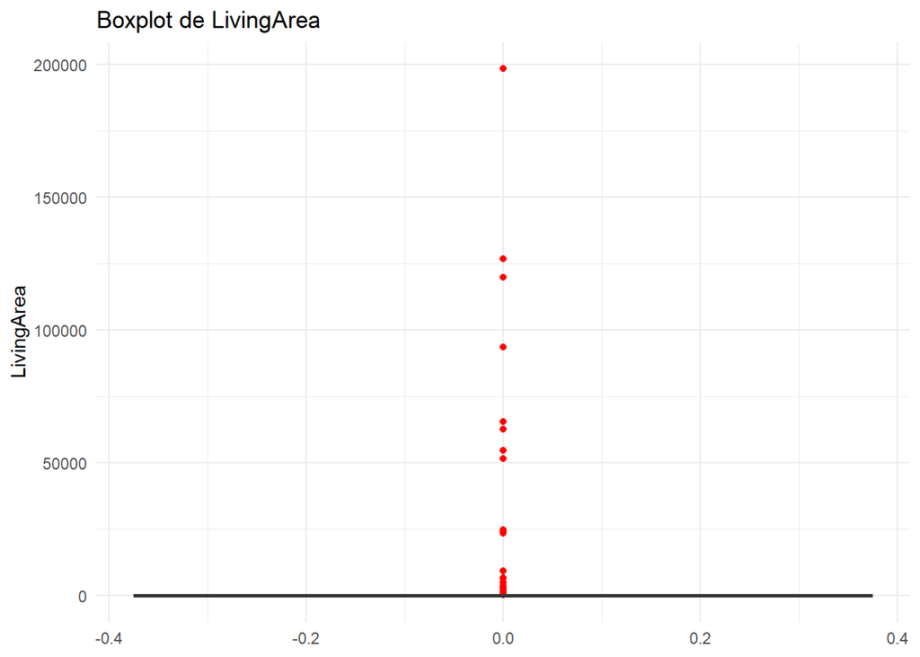

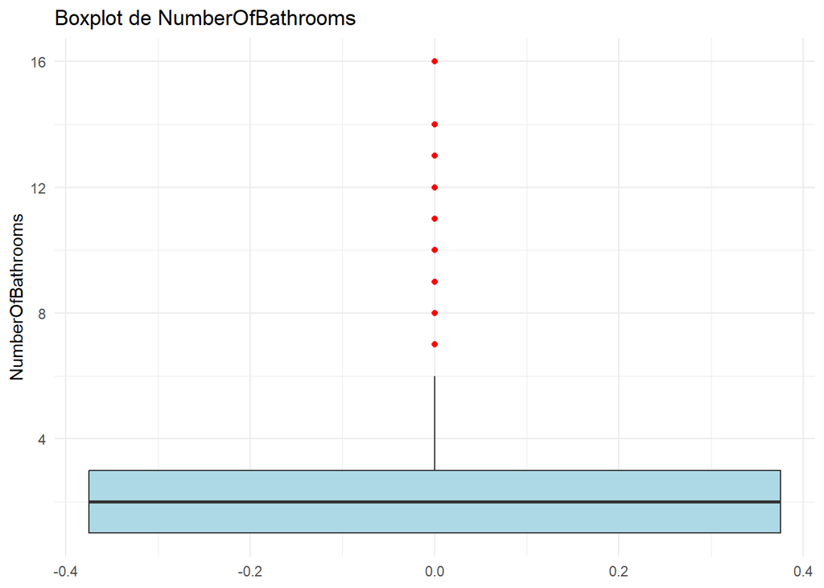

```r
# Filtrar solo "House" y "Apartment" en Type
data <- data %>% filter(Type %in% c("House", "Apartment"))

# Visualización de boxplots para cada variable
variables_to_plot <- c("TotalRooms", "TotalArea", "LivingArea", "NumberOfBathrooms")

for (var in variables_to_plot) {
  p <- ggplot(data, aes(y = .data[[var]])) +
    geom_boxplot(fill = "lightblue", outlier.color = "red", outlier.shape = 16) +
    theme_minimal() +
    labs(title = paste("Boxplot de", var), y = var)

  print(p)
}
```

Podemos observar que tenemos outliers en las cuatro variables. Vamos a crear una función que detecte los outliers y luego iremos iterando hasta que no quede ninguno.

```r
# Función para calcular outliers
calculate_outliers <- function(x) {
  q1 <- quantile(x, 0.25, na.rm = TRUE)
  q3 <- quantile(x, 0.75, na.rm = TRUE)
  iqr <- q3 - q1
  lower_bound <- q1 - 1.5 * iqr
  upper_bound <- q3 + 1.5 * iqr
  outliers <- sum(x < lower_bound | x > upper_bound, na.rm = TRUE)
  return(list(outliers = outliers, lower_bound = lower_bound, upper_bound = upper_bound))
}

# Iteramos hasta que no queden outliers en ninguna variable
variables_to_check <- c("TotalRooms", "TotalArea", "LivingArea", "NumberOfBathrooms")
outliers_remaining <- TRUE

while (outliers_remaining) {
  outlier_counts <- sapply(variables_to_check, function(var) {
    result <- calculate_outliers(data[[var]])
    data <<- data %>% filter(data[[var]] >= result$lower_bound & data[[var]] <= result$upper_bound)
    return(result$outliers)
  })

  cat("Outliers restantes:\n")
  print(outlier_counts)

  # Si no quedan outliers, salimos del bucle
  outliers_remaining <- any(outlier_counts > 0)
}
```

```
## Outliers restantes:
##        TotalRooms         TotalArea        LivingArea NumberOfBathrooms
##               725              3537              1372              1805
## Outliers restantes:
##        TotalRooms         TotalArea        LivingArea NumberOfBathrooms
##              1738              1328               458                 0
## Outliers restantes:
##        TotalRooms         TotalArea        LivingArea NumberOfBathrooms
##                 0               354               138                 0
## Outliers restantes:
##        TotalRooms         TotalArea        LivingArea NumberOfBathrooms
##                 0               128                35                 0
## Outliers restantes:
##        TotalRooms         TotalArea        LivingArea NumberOfBathrooms
##                 0                35                39                 0
## Outliers restantes:
##        TotalRooms         TotalArea        LivingArea NumberOfBathrooms
##                 0                 0                 0                 0
```

**Ya no tenemos outliers**. Observando que tenemos LivingArea y TotalArea, nos vamos a asegurar de que LivingArea nunca supere a TotalArea, cosa que no tendria sentido.

```r
# Nos quedamos con los registros que TotalArea sea superior o igual a LivingArea
data <- data %>% filter(LivingArea <= TotalArea)
summary(data)
```

```
##      Price           District             City               Type
##  Min.   :  50000   Length:17586       Length:17586       Length:17586
##  1st Qu.: 187500   Class :character   Class :character   Class :character
##  Median : 255000   Mode  :character   Mode  :character   Mode  :character
##  Mean   : 322934
##  3rd Qu.: 379000
##  Max.   :3000000
##  EnergyCertificate     Parking       ConstructionYear   TotalArea
##  Length:17586       Min.   :0.0000   Min.   :1950     Min.   : 11.00
##  Class :character   1st Qu.:0.0000   1st Qu.:1983     1st Qu.: 73.00
##  Mode  :character   Median :0.0000   Median :1996     Median : 95.00
##                     Mean   :0.5498   Mean   :1996     Mean   : 99.82
##                     3rd Qu.:1.0000   3rd Qu.:2011     3rd Qu.:123.00
##                     Max.   :3.0000   Max.   :2024     Max.   :195.00
##    Elevator           TotalRooms      LivingArea     NumberOfBathrooms
##  Length:17586       Min.   :1.000   Min.   :  6.00   Min.   :1.000
##  Class :character   1st Qu.:2.000   1st Qu.: 67.00   1st Qu.:1.000
##  Mode  :character   Median :3.000   Median : 86.00   Median :2.000
##                     Mean   :2.599   Mean   : 89.28   Mean   :1.676
##                     3rd Qu.:3.000   3rd Qu.:109.00   3rd Qu.:2.000
##                     Max.   :4.000   Max.   :173.00   Max.   :3.000
##       lat             long
##  Min.   :37.02   Min.   :-9.137
##  1st Qu.:38.71   1st Qu.:-9.137
##  Median :38.71   Median :-8.893
##  Mean   :39.20   Mean   :-8.828
##  3rd Qu.:40.21   3rd Qu.:-8.611
##  Max.   :41.69   Max.   :-7.446
```

Observamos como de un conjunto de datos inicial de 125.457 registros y 25 variables **hemos pasado a otro de 17.586 registros y 14 variables**. Una vez estamos de acuerdo con el resultado y definimos este conjunto como el conjunto de datos final, pasamos a extraer en formato csv el conjunto para trabajar con él más adelante en Tableau Public.

```r
# Exportar dataset limpio con codificación UTF-8
write.csv(data, "portugal_cleaned_listings.csv", row.names = FALSE, fileEncoding = "UTF-8")
```